# Problem Statement :

A US-based housing company named Surprise Housing has decided to enter the Australian market. The company uses data analytics to purchase houses at a price below their actual values and flip them at a higher price. The company wants to know

```
    - Which variables are significant in predicting the price of a house, and
    - How well those variables describe the price of a house.
```

## Business Goal :

Build a regression model using regularisation in order to predict the actual value of the prospective properties and decide whether to invest in them or not.Determine the optimal value of lambda for ridge and lasso regression.This model will then be used by the management to understand how exactly the prices vary with the variables

## Reading and Exploring the data

```python
# importing the requisite libraries

import numpy as np
import pandas as pd
import matplotlib.pyplot as plt
import seaborn as sns
%matplotlib inline
from sklearn.preprocessing import scale
from sklearn.model_selection import train_test_split
from sklearn.linear_model import Ridge, Lasso
from sklearn.metrics import mean_squared_error
from sklearn.model_selection import GridSearchCV
from sklearn.feature_selection import RFE
from sklearn.linear_model import LinearRegression
import scipy.stats as stats
import warnings
warnings.filterwarnings('ignore')
```

Data Understanding and Exploration

```python
# Reading the dataset
houseInfoDF = pd.read_csv('train.csv', encoding = 'utf-8')
houseInfoDF.head()
```

|  | Id | MSSubClass | MSZoning | LotFrontage | LotArea | Street | Alley | LotShape | LandContour | Utilities | ... | PoolArea | PoolQC | Fence | MiscFeature | MiscVal | MoSold | YrSold | SaleType | SaleCondition | SalePrice |
| --- | --- | --- | --- | --- | --- | --- | --- | --- | --- | --- | --- | --- | --- | --- | --- | --- | --- | --- | --- | --- | --- |
| 0 | 1 | 60 | RL | 65.0 | 8450 | Pave | NaN | Reg | Lvl | AllPub | ... | 0 | NaN | NaN | NaN | 0 | 2 | 2008 | WD | Normal | 208500 |
| 1 | 2 | 20 | RL | 80.0 | 9600 | Pave | NaN | Reg | Lvl | AllPub | ... | 0 | NaN | NaN | NaN | 0 | 5 | 2007 | WD | Normal | 181500 |
| 2 | 3 | 60 | RL | 68.0 | 11250 | Pave | NaN | IR1 | Lvl | AllPub | ... | 0 | NaN | NaN | NaN | 0 | 9 | 2008 | WD | Normal | 223500 |
| 3 | 4 | 70 | RL | 60.0 | 9550 | Pave | NaN | IR1 | Lvl | AllPub | ... | 0 | NaN | NaN | NaN | 0 | 2 | 2006 | WD | Abnorml | 140000 |
| 4 | 5 | 60 | RL | 84.0 | 14260 | Pave | NaN | IR1 | Lvl | AllPub | ... | 0 | NaN | NaN | NaN | 0 | 12 | 2008 | WD | Normal | 250000 |

5 rows × 81 columns

```python
print('#####info####')
print(houseInfoDF.info())
print('#####shape####')
print(houseInfoDF.shape)
print('#####describe####')
print(houseInfoDF.describe())
```

```
#####info####
<class 'pandas.core.frame.DataFrame'>
RangeIndex: 1460 entries, 0 to 1459
Data columns (total 81 columns):
 #   Column         Non-Null Count  Dtype
---  ------         --------------  -----
 0   Id             1460 non-null   int64
 1   MSSubClass     1460 non-null   int64
 2   MSZoning       1460 non-null   object
 3   LotFrontage    1201 non-null   float64
 4   LotArea        1460 non-null   int64
 5   Street         1460 non-null   object
 6   Alley          91 non-null     object
 7   LotShape       1460 non-null   object
 8   LandContour    1460 non-null   object
 9   Utilities      1460 non-null   object
 10  LotConfig      1460 non-null   object
 11  LandSlope      1460 non-null   object
 12  Neighborhood   1460 non-null   object
 13  Condition1     1460 non-null   object
 14  Condition2     1460 non-null   object
 15  BldgType       1460 non-null   object
 16  HouseStyle     1460 non-null   object
 17  OverallQual    1460 non-null   int64
 18  OverallCond    1460 non-null   int64
 19  YearBuilt      1460 non-null   int64
 20  YearRemodAdd   1460 non-null   int64
 21  RoofStyle      1460 non-null   object
 22  RoofMatl       1460 non-null   object
 23  Exterior1st    1460 non-null   object
 24  Exterior2nd    1460 non-null   object
 25  MasVnrType     1452 non-null   object
 26  MasVnrArea     1452 non-null   float64
 27  ExterQual      1460 non-null   object
 28  ExterCond      1460 non-null   object
 29  Foundation     1460 non-null   object
 30  BsmtQual       1423 non-null   object
 31  BsmtCond       1423 non-null   object
 32  BsmtExposure   1422 non-null   object
 33  BsmtFinType1   1423 non-null   object
```

[output cut: 79 more lines]

```
50%       0.000000    25.000000       0.000000     0.000000     0.000000
75%     168.000000    68.000000       0.000000     0.000000     0.000000
max     857.000000   547.000000     552.000000   508.000000   480.000000

          PoolArea       MiscVal       MoSold       YrSold      SalePrice
count  1460.000000   1460.000000  1460.000000  1460.000000    1460.000000
mean      2.758904     43.489041     6.321918  2007.815753  180921.195890
std      40.177307    496.123024     2.703626     1.328095   79442.502883
min       0.000000      0.000000     1.000000  2006.000000   34900.000000
25%       0.000000      0.000000     5.000000  2007.000000  129975.000000
50%       0.000000      0.000000     6.000000  2008.000000  163000.000000
75%       0.000000      0.000000     8.000000  2009.000000  214000.000000
max     738.000000  15500.000000    12.000000  2010.000000  755000.000000

[8 rows x 38 columns]
```

# Data Cleaning

```python
# check for null values in all categorical columns

houseInfoDF.select_dtypes(include='object').isnull().sum()[houseInfoDF.select_dtypes(include='object').isnull().sum()>0]
```

```
Alley           1369
MasVnrType         8
BsmtQual          37
BsmtCond          37
BsmtExposure      38
BsmtFinType1      37
BsmtFinType2      38
Electrical         1
FireplaceQu      690
GarageType        81
GarageFinish      81
GarageQual        81
GarageCond        81
PoolQC          1453
Fence           1179
MiscFeature     1406
dtype: int64
```

```python
# Replace null with None in the following columns below :

for col in ('Alley', 'MasVnrType', 'BsmtQual', 'BsmtCond', 'BsmtExposure', 'BsmtFinType1', 'BsmtFinType2', 'FireplaceQu',
            'GarageType', 'GarageFinish', 'GarageQual', 'GarageCond', 'PoolQC', 'Fence', 'MiscFeature', 'Electrical'):

    houseInfoDF[col]=houseInfoDF[col].fillna('None')
```

Duplicates Check

```python
# Check if there are any duplicate values in the dataset

houseInfoDF[houseInfoDF.duplicated(keep=False)]
```

|  | Id | MSSubClass | MSZoning | LotFrontage | LotArea | Street | Alley | LotShape | LandContour | Utilities | ... | PoolArea | PoolQC | Fence | MiscFeature | MiscVal | MoSold | YrSold | SaleType | SaleCondition | SalePrice |
| --- | --- | --- | --- | --- | --- | --- | --- | --- | --- | --- | --- | --- | --- | --- | --- | --- | --- | --- | --- | --- | --- |

0 rows × 81 columns

```python
# once again check for null values in all categorical columns

houseInfoDF.select_dtypes(include='object').isnull().sum()[houseInfoDF.select_dtypes(include='object').isnull().sum()>0]
```

```
Series([], dtype: int64)
```

No more null values in the categorical variables NOW , We inspect and try Removing null values in Numerical attributes

```python
# check the null values in the numerical data

houseInfoDF.select_dtypes(include=['int64','float']).isnull().sum()[houseInfoDF.select_dtypes(include=['int64','float']).isnull()
                                                                  .sum()>0]
```

```
LotFrontage    259
MasVnrArea       8
GarageYrBlt     81
dtype: int64
```

```python
##Inspecting the value to be replaced

print(houseInfoDF['LotFrontage'].median())
print((houseInfoDF['LotFrontage'].value_counts))
```

```
69.0
<bound method IndexOpsMixin.value_counts of 0       65.0
1       80.0
2       68.0
3       60.0
4       84.0
        ...
1455    62.0
1456    85.0
1457    66.0
1458    68.0
1459    75.0
Name: LotFrontage, Length: 1460, dtype: float64>
```

```python
print(houseInfoDF['MasVnrArea'].median())
print(houseInfoDF['MasVnrArea'].value_counts)
```

```
0.0
<bound method IndexOpsMixin.value_counts of 0       196.0
1         0.0
2       162.0
3         0.0
4       350.0
        ...
1455      0.0
1456    119.0
1457      0.0
1458      0.0
1459      0.0
Name: MasVnrArea, Length: 1460, dtype: float64>
```

```python
print(houseInfoDF['GarageYrBlt'].median())
print(houseInfoDF['GarageYrBlt'].value_counts)
```

```
1980.0
<bound method IndexOpsMixin.value_counts of 0       2003.0
1       1976.0
2       2001.0
3       1998.0
4       2000.0
         ...
1455    1999.0
1456    1978.0
1457    1941.0
1458    1950.0
1459    1965.0
Name: GarageYrBlt, Length: 1460, dtype: float64>
```

```python
# Impute the null values with median values for LotFrontage and MasVnrArea columns

houseInfoDF['LotFrontage'] = houseInfoDF['LotFrontage'].replace(np.nan, houseInfoDF['LotFrontage'].median())
houseInfoDF['MasVnrArea'] = houseInfoDF['MasVnrArea'].replace(np.nan, houseInfoDF['MasVnrArea'].median())
```

```python
# Setting the null values with 0 for GarageYrBlt for now as we would be handling this column further below

houseInfoDF['GarageYrBlt']=houseInfoDF['GarageYrBlt'].fillna(0)
houseInfoDF['GarageYrBlt'] = houseInfoDF['GarageYrBlt'].astype(int)
```

Dervied Columns For simplification

```python
# Create a new column which would indicate if the Garage is old or new.
# Garage Yr Built less than 2000 will be considered as old (0) else new(1).
# For GarageYrBuilt , where we have imputed the value as 0 will also be treated as old.

def getGarageConstructionPeriod(row):
    if row == 0:
        return 0
    elif row >= 1900 and row < 2000:
        return 0
    else:
        return 1

houseInfoDF['IsNewGarage'] = houseInfoDF['GarageYrBlt'].apply(getGarageConstructionPeriod)
houseInfoDF.head()
```

|  | Id | MSSubClass | MSZoning | LotFrontage | LotArea | Street | Alley | LotShape | LandContour | Utilities | ... | PoolQC | Fence | MiscFeature | MiscVal | MoSold | YrSold | SaleType | SaleCondition | SalePrice | IsNewGarage |
| --- | --- | --- | --- | --- | --- | --- | --- | --- | --- | --- | --- | --- | --- | --- | --- | --- | --- | --- | --- | --- | --- |
| 0 | 1 | 60 | RL | 65.0 | 8450 | Pave | None | Reg | Lvl | AllPub | ... | None | None | None | 0 | 2 | 2008 | WD | Normal | 208500 | 1 |
| 1 | 2 | 20 | RL | 80.0 | 9600 | Pave | None | Reg | Lvl | AllPub | ... | None | None | None | 0 | 5 | 2007 | WD | Normal | 181500 | 0 |
| 2 | 3 | 60 | RL | 68.0 | 11250 | Pave | None | IR1 | Lvl | AllPub | ... | None | None | None | 0 | 9 | 2008 | WD | Normal | 223500 | 1 |
| 3 | 4 | 70 | RL | 60.0 | 9550 | Pave | None | IR1 | Lvl | AllPub | ... | None | None | None | 0 | 2 | 2006 | WD | Abnorml | 140000 | 0 |
| 4 | 5 | 60 | RL | 84.0 | 14260 | Pave | None | IR1 | Lvl | AllPub | ... | None | None | None | 0 | 12 | 2008 | WD | Normal | 250000 | 1 |

5 rows × 82 columns

```python
# Create a new column named IsReTouched - This column would determine whether the house has been remodelled or not based on
# the difference between remodelled and built years

def checkForRemodel(row):
    if(row['YearBuilt'] == row['YearRemodAdd']):
        return 0
    elif(row['YearBuilt'] < row['YearRemodAdd']):
        return 1
    else:
        return 2

houseInfoDF['IsReTouched'] = houseInfoDF.apply(checkForRemodel, axis=1)
houseInfoDF.head()
```

|  | Id | MSSubClass | MSZoning | LotFrontage | LotArea | Street | Alley | LotShape | LandContour | Utilities | ... | Fence | MiscFeature | MiscVal | MoSold | YrSold | SaleType | SaleCondition | SalePrice | IsNewGarage | IsReTouched |
| --- | --- | --- | --- | --- | --- | --- | --- | --- | --- | --- | --- | --- | --- | --- | --- | --- | --- | --- | --- | --- | --- |
| 0 | 1 | 60 | RL | 65.0 | 8450 | Pave | None | Reg | Lvl | AllPub | ... | None | None | 0 | 2 | 2008 | WD | Normal | 208500 | 1 | 0 |
| 1 | 2 | 20 | RL | 80.0 | 9600 | Pave | None | Reg | Lvl | AllPub | ... | None | None | 0 | 5 | 2007 | WD | Normal | 181500 | 0 | 0 |
| 2 | 3 | 60 | RL | 68.0 | 11250 | Pave | None | IR1 | Lvl | AllPub | ... | None | None | 0 | 9 | 2008 | WD | Normal | 223500 | 1 | 1 |
| 3 | 4 | 70 | RL | 60.0 | 9550 | Pave | None | IR1 | Lvl | AllPub | ... | None | None | 0 | 2 | 2006 | WD | Abnorml | 140000 | 0 | 1 |
| 4 | 5 | 60 | RL | 84.0 | 14260 | Pave | None | IR1 | Lvl | AllPub | ... | None | None | 0 | 12 | 2008 | WD | Normal | 250000 | 1 | 0 |

5 rows × 83 columns

```python
# Create a new column named BuiltOrReTouchedAge and determine the age of the building at the time of selling

def getBuiltOrRemodelAge(row):
    if(row['YearBuilt'] == row['YearRemodAdd']):
        return row['YrSold'] - row['YearBuilt']
    else:
        return row['YrSold'] - row['YearRemodAdd']

houseInfoDF['BuiltOrReTouchedAge'] = houseInfoDF.apply(getBuiltOrRemodelAge, axis=1)
houseInfoDF.head()
```

|  | Id | MSSubClass | MSZoning | LotFrontage | LotArea | Street | Alley | LotShape | LandContour | Utilities | ... | MiscFeature | MiscVal | MoSold | YrSold | SaleType | SaleCondition | SalePrice | IsNewGarage | IsReTouched | BuiltOrReTouchedAge |
| --- | --- | --- | --- | --- | --- | --- | --- | --- | --- | --- | --- | --- | --- | --- | --- | --- | --- | --- | --- | --- | --- |
| 0 | 1 | 60 | RL | 65.0 | 8450 | Pave | None | Reg | Lvl | AllPub | ... | None | 0 | 2 | 2008 | WD | Normal | 208500 | 1 | 0 | 5 |
| 1 | 2 | 20 | RL | 80.0 | 9600 | Pave | None | Reg | Lvl | AllPub | ... | None | 0 | 5 | 2007 | WD | Normal | 181500 | 0 | 0 | 31 |
| 2 | 3 | 60 | RL | 68.0 | 11250 | Pave | None | IR1 | Lvl | AllPub | ... | None | 0 | 9 | 2008 | WD | Normal | 223500 | 1 | 1 | 6 |
| 3 | 4 | 70 | RL | 60.0 | 9550 | Pave | None | IR1 | Lvl | AllPub | ... | None | 0 | 2 | 2006 | WD | Abnorml | 140000 | 0 | 1 | 36 |
| 4 | 5 | 60 | RL | 84.0 | 14260 | Pave | None | IR1 | Lvl | AllPub | ... | None | 0 | 12 | 2008 | WD | Normal | 250000 | 1 | 0 | 8 |

5 rows × 84 columns

```python
# Since we have created new features from YearBuilt, YearRemodAdd, YrSold and GarageYrBlt, we can drop these columns as we
# would only be using the derived columns for further analysis

houseInfoDF.drop(['YearBuilt', 'YearRemodAdd', 'YrSold', 'GarageYrBlt'], axis = 1, inplace = True)
```

```python
# check for percentage of null values in each column

final_null_check_percentage = round(100*(houseInfoDF.isnull().sum()/len(houseInfoDF.index)), 2)
print(list(final_null_check_percentage))
```

```
[0.0, 0.0, 0.0, 0.0, 0.0, 0.0, 0.0, 0.0, 0.0, 0.0, 0.0, 0.0, 0.0, 0.0, 0.0, 0.0, 0.0, 0.0, 0.0, 0.0, 0.0, 0.0, 0.0, 0.0, 0.0, 0.0, 0.0, 0.0, 0.0, 0.0, 0.0, 0.0, 0.0, 0.0, 0.0, 0.0, 0.0, 0.0, 0.0, 0.0, 0.0, 0.0, 0.0, 0.0, 0.0, 0.0, 0.0, 0.0, 0.0, 0.0, 0.0, 0.0, 0.0, 0.0, 0.0, 0.0, 0.0, 0.0, 0.0, 0.0,…
```

#### Outliear Treatment and Remove the columns with skewed data

```python
# Drop the following columns that have more than 85% values associated to a specific value

countCheck = int((85/100) * int(len(houseInfoDF)))
print(countCheck)
```

```
1241
```

```python
# Drop the following columns that have more than 85% values associated to a specific value

def getHighNumericalValueCounts():
    column = []
    numerical_columns = houseInfoDF.select_dtypes(include=['int64', 'float'])
    for col in (numerical_columns):
        if(houseInfoDF[col].value_counts().max() >= countCheck):
            column.append(col)
    return column

columnsToBeRemoved = getHighNumericalValueCounts()
houseInfoDF.drop(columnsToBeRemoved, axis = 1, inplace = True)


def getHighCategoricalValueCounts():
    column = []
    categorical_columns = houseInfoDF.select_dtypes(include=['object'])
    for col in (categorical_columns):
        if(houseInfoDF[col].value_counts().max() >= countCheck):
            column.append(col)
    return column

columnsToBeRemoved = getHighCategoricalValueCounts()

houseInfoDF.drop(columnsToBeRemoved, axis = 1, inplace = True)
houseInfoDF.head()
```

|  | Id | MSSubClass | MSZoning | LotFrontage | LotArea | LotShape | LotConfig | Neighborhood | BldgType | HouseStyle | ... | GarageArea | WoodDeckSF | OpenPorchSF | Fence | MoSold | SaleCondition | SalePrice | IsNewGarage | IsReTouched | BuiltOrReTouchedAge |
| --- | --- | --- | --- | --- | --- | --- | --- | --- | --- | --- | --- | --- | --- | --- | --- | --- | --- | --- | --- | --- | --- |
| 0 | 1 | 60 | RL | 65.0 | 8450 | Reg | Inside | CollgCr | 1Fam | 2Story | ... | 548 | 0 | 61 | None | 2 | Normal | 208500 | 1 | 0 | 5 |
| 1 | 2 | 20 | RL | 80.0 | 9600 | Reg | FR2 | Veenker | 1Fam | 1Story | ... | 460 | 298 | 0 | None | 5 | Normal | 181500 | 0 | 0 | 31 |
| 2 | 3 | 60 | RL | 68.0 | 11250 | IR1 | Inside | CollgCr | 1Fam | 2Story | ... | 608 | 0 | 42 | None | 9 | Normal | 223500 | 1 | 1 | 6 |
| 3 | 4 | 70 | RL | 60.0 | 9550 | IR1 | Corner | Crawfor | 1Fam | 2Story | ... | 642 | 0 | 35 | None | 2 | Abnorml | 140000 | 0 | 1 | 36 |
| 4 | 5 | 60 | RL | 84.0 | 14260 | IR1 | FR2 | NoRidge | 1Fam | 2Story | ... | 836 | 192 | 84 | None | 12 | Normal | 250000 | 1 | 0 | 8 |

5 rows × 50 columns

```python
# check for percentage of null values in each column

final_null_check_percentage = round(100*(houseInfoDF.isnull().sum()/len(houseInfoDF.index)), 2)
print(final_null_check_percentage)
```

```
Id                     0.0
MSSubClass             0.0
MSZoning               0.0
LotFrontage            0.0
LotArea                0.0
LotShape               0.0
LotConfig              0.0
Neighborhood           0.0
BldgType               0.0
HouseStyle             0.0
OverallQual            0.0
OverallCond            0.0
RoofStyle              0.0
Exterior1st            0.0
Exterior2nd            0.0
MasVnrType             0.0
MasVnrArea             0.0
ExterQual              0.0
Foundation             0.0
BsmtQual               0.0
BsmtExposure           0.0
BsmtFinType1           0.0
BsmtFinSF1             0.0
BsmtUnfSF              0.0
TotalBsmtSF            0.0
HeatingQC              0.0
1stFlrSF               0.0
2ndFlrSF               0.0
GrLivArea              0.0
BsmtFullBath           0.0
FullBath               0.0
HalfBath               0.0
BedroomAbvGr           0.0
KitchenQual            0.0
TotRmsAbvGrd           0.0
Fireplaces             0.0
FireplaceQu            0.0
GarageType             0.0
GarageFinish           0.0
GarageCars             0.0
GarageArea             0.0
WoodDeckSF             0.0
OpenPorchSF            0.0
Fence                  0.0
MoSold                 0.0
SaleCondition          0.0
SalePrice              0.0
IsNewGarage            0.0
IsReTouched            0.0
BuiltOrReTouchedAge    0.0
dtype: float64
```

```python
# Checking outliers at 25%,50%,75%,90%,95% and above

houseInfoDF.describe(percentiles=[.25,.5,.75,.90,.95,.99])
```

|  | Id | MSSubClass | LotFrontage | LotArea | OverallQual | OverallCond | MasVnrArea | BsmtFinSF1 | BsmtUnfSF | TotalBsmtSF | ... | Fireplaces | GarageCars | GarageArea | WoodDeckSF | OpenPorchSF | MoSold | SalePrice | IsNewGarage | IsReTouched | BuiltOrReTouchedAge |
| --- | --- | --- | --- | --- | --- | --- | --- | --- | --- | --- | --- | --- | --- | --- | --- | --- | --- | --- | --- | --- | --- |
| count | 1460.000000 | 1460.000000 | 1460.000000 | 1460.000000 | 1460.000000 | 1460.000000 | 1460.000000 | 1460.000000 | 1460.000000 | 1460.000000 | ... | 1460.000000 | 1460.000000 | 1460.000000 | 1460.000000 | 1460.000000 | 1460.000000 | 1460.000000 | 1460.000000 | 1460.000000 | 1460.000000 |
| mean | 730.500000 | 56.897260 | 69.863699 | 10516.828082 | 6.099315 | 5.575342 | 103.117123 | 443.639726 | 567.240411 | 1057.429452 | ... | 0.613014 | 1.767123 | 472.980137 | 94.244521 | 46.660274 | 6.321918 | 180921.195890 | 0.275342 | 0.476712 | 22.950000 |
| std | 421.610009 | 42.300571 | 22.027677 | 9981.264932 | 1.382997 | 1.112799 | 180.731373 | 456.098091 | 441.866955 | 438.705324 | ... | 0.644666 | 0.747315 | 213.804841 | 125.338794 | 66.256028 | 2.703626 | 79442.502883 | 0.446840 | 0.499629 | 20.640653 |
| min | 1.000000 | 20.000000 | 21.000000 | 1300.000000 | 1.000000 | 1.000000 | 0.000000 | 0.000000 | 0.000000 | 0.000000 | ... | 0.000000 | 0.000000 | 0.000000 | 0.000000 | 0.000000 | 1.000000 | 34900.000000 | 0.000000 | 0.000000 | -1.000000 |
| 25% | 365.750000 | 20.000000 | 60.000000 | 7553.500000 | 5.000000 | 5.000000 | 0.000000 | 0.000000 | 223.000000 | 795.750000 | ... | 0.000000 | 1.000000 | 334.500000 | 0.000000 | 0.000000 | 5.000000 | 129975.000000 | 0.000000 | 0.000000 | 4.000000 |
| 50% | 730.500000 | 50.000000 | 69.000000 | 9478.500000 | 6.000000 | 5.000000 | 0.000000 | 383.500000 | 477.500000 | 991.500000 | ... | 1.000000 | 2.000000 | 480.000000 | 0.000000 | 25.000000 | 6.000000 | 163000.000000 | 0.000000 | 0.000000 | 14.000000 |
| 75% | 1095.250000 | 70.000000 | 79.000000 | 11601.500000 | 7.000000 | 6.000000 | 164.250000 | 712.250000 | 808.000000 | 1298.250000 | ... | 1.000000 | 2.000000 | 576.000000 | 168.000000 | 68.000000 | 8.000000 | 214000.000000 | 1.000000 | 1.000000 | 41.000000 |
| 90% | 1314.100000 | 120.000000 | 92.000000 | 14381.700000 | 8.000000 | 7.000000 | 335.000000 | 1065.500000 | 1232.000000 | 1602.200000 | ... | 1.000000 | 3.000000 | 757.100000 | 262.000000 | 130.000000 | 10.000000 | 278000.000000 | 1.000000 | 1.000000 | 56.000000 |
| 95% | 1387.050000 | 160.000000 | 104.000000 | 17401.150000 | 8.000000 | 8.000000 | 456.000000 | 1274.000000 | 1468.000000 | 1753.000000 | ... | 2.000000 | 3.000000 | 850.100000 | 335.000000 | 175.050000 | 11.000000 | 326100.000000 | 1.000000 | 1.000000 | 58.000000 |
| 99% | 1445.410000 | 190.000000 | 137.410000 | 37567.640000 | 10.000000 | 9.000000 | 791.280000 | 1572.410000 | 1797.050000 | 2155.050000 | ... | 2.000000 | 3.000000 | 1002.790000 | 505.460000 | 285.820000 | 12.000000 | 442567.010000 | 1.000000 | 1.000000 | 60.000000 |
| max | 1460.000000 | 190.000000 | 313.000000 | 215245.000000 | 10.000000 | 9.000000 | 1600.000000 | 5644.000000 | 2336.000000 | 6110.000000 | ... | 3.000000 | 4.000000 | 1418.000000 | 857.000000 | 547.000000 | 12.000000 | 755000.000000 | 1.000000 | 1.000000 | 60.000000 |

11 rows × 28 columns

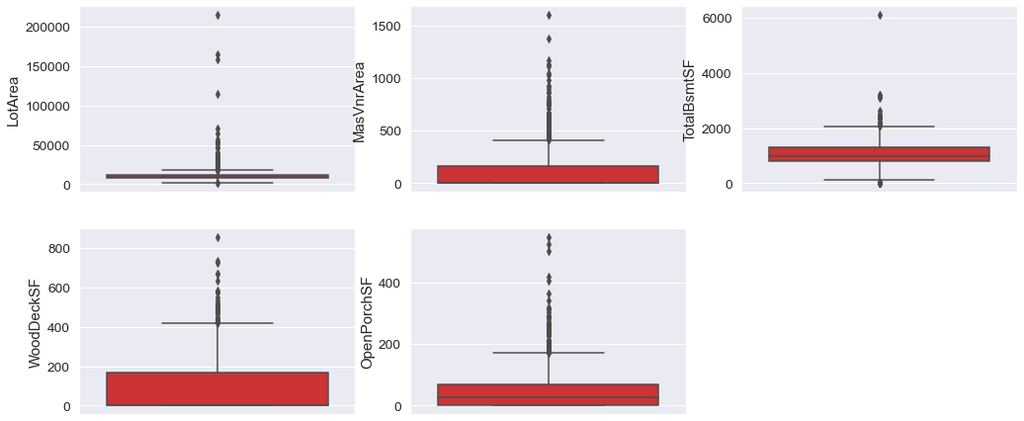

```python
# Check the outliers in all the numeric columns

plt.figure(figsize=(17, 20))
plt.subplot(5,3,1)
sns.boxplot(y = 'LotArea', palette='Set1', data = houseInfoDF)
plt.subplot(5,3,2)
sns.boxplot(y = 'MasVnrArea', palette='Set1', data = houseInfoDF)
plt.subplot(5,3,3)
sns.boxplot(y = 'TotalBsmtSF', palette='Set1', data = houseInfoDF)
plt.subplot(5,3,4)
sns.boxplot(y = 'WoodDeckSF', palette='Set1', data = houseInfoDF)
plt.subplot(5,3,5)
sns.boxplot(y = 'OpenPorchSF', palette='Set1', data = houseInfoDF)
plt.show()
```

```python
# Removing Outliers carefully as we have quite a small set of data

# Removing values beyond 98% for LotArea

nn_quartile_LotArea = houseInfoDF['LotArea'].quantile(0.98)
houseInfoDF = houseInfoDF[houseInfoDF["LotArea"] < nn_quartile_LotArea]

# Removing values beyond 98% for MasVnrArea

nn_quartile_MasVnrArea = houseInfoDF['MasVnrArea'].quantile(0.98)
houseInfoDF = houseInfoDF[houseInfoDF["MasVnrArea"] < nn_quartile_MasVnrArea]

# Removing values beyond 99% for TotalBsmtSF

nn_quartile_TotalBsmtSF = houseInfoDF['TotalBsmtSF'].quantile(0.99)
houseInfoDF = houseInfoDF[houseInfoDF["TotalBsmtSF"] < nn_quartile_TotalBsmtSF]

# Removing values beyond 99% for WoodDeckSF

nn_quartile_WoodDeckSF = houseInfoDF['WoodDeckSF'].quantile(0.99)
houseInfoDF = houseInfoDF[houseInfoDF["WoodDeckSF"] < nn_quartile_WoodDeckSF]

# Removing values beyond 99% for OpenPorchSF

nn_quartile_OpenPorchSF = houseInfoDF['OpenPorchSF'].quantile(0.99)
houseInfoDF = houseInfoDF[houseInfoDF["OpenPorchSF"] < nn_quartile_OpenPorchSF]
```

```python
# Determine the percentage of data retained

num_data = round(100*(len(houseInfoDF)/1460),2)
print(num_data)
```

```
93.01
```

# Data Visualisation

```
(array([ 0,  1,  2,  3,  4,  5,  6,  7,  8,  9, 10, 11, 12, 13, 14, 15, 16,
        17, 18, 19, 20, 21, 22, 23, 24]),
 [Text(0, 0, 'CollgCr'),
```

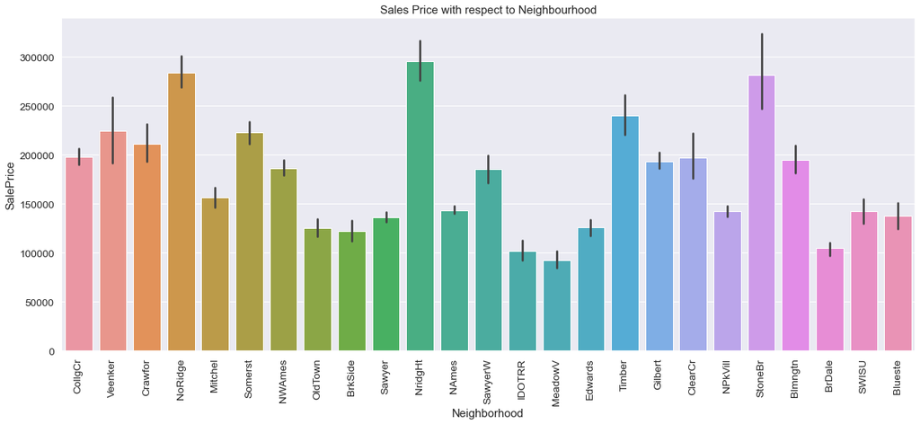

```python
# plot 'Sale Price' with respect to 'Neighborhood'

plt.figure(figsize=(20, 8))
sns.barplot(x="Neighborhood", y="SalePrice", data= houseInfoDF)
plt.title("Sales Price with respect to Neighbourhood")
plt.xticks(rotation=90)
```

### We see , Properties in some of the Neighborhoods are high priced.

```
(array([0, 1, 2, 3, 4, 5, 6, 7, 8, 9]),
 [Text(0, 0, '1'),
```

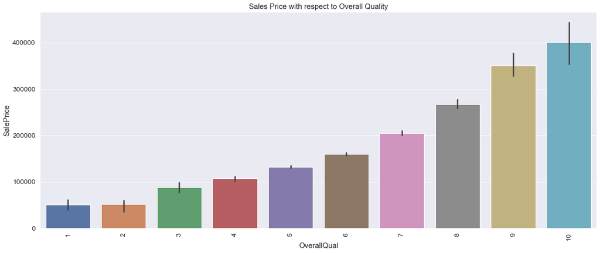

```python
# plot 'overall quality' with respect to 'Saleprice'

plt.figure(figsize=(20, 8))
sns.barplot(x="OverallQual", y="SalePrice", data= houseInfoDF)
plt.title("Sales Price with respect to Overall Quality")
plt.xticks(rotation=90)
```

### We see , Increase in the overall quality has a direct positive effect on the sale price

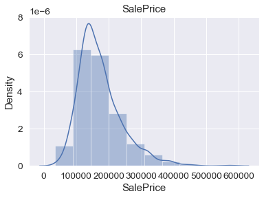

```python
plt.title('SalePrice')
sns.distplot(houseInfoDF['SalePrice'], bins=10)
plt.show()
```

### SalePrice is a bit skwed , So we do a Transforming of the sale price

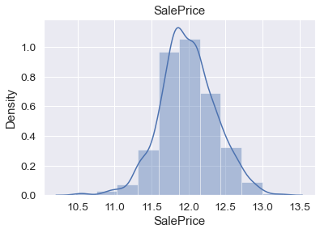

```python
# Visualise the target variable -> SalePrice after transforming the sales price

houseInfoDF['SalePrice'] = np.log1p(houseInfoDF['SalePrice'])

plt.title('SalePrice')
sns.distplot(houseInfoDF['SalePrice'], bins=10)
plt.show()
```

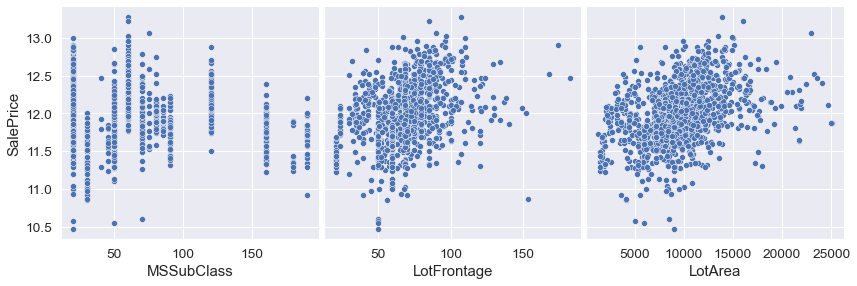

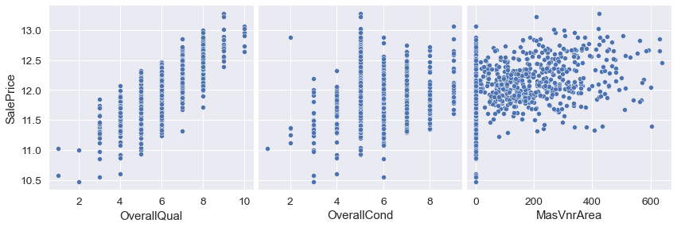

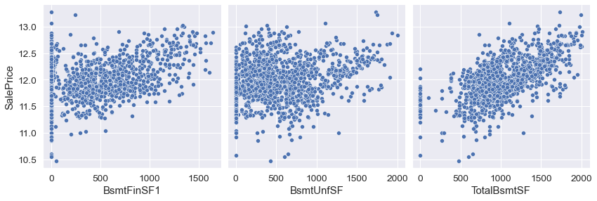

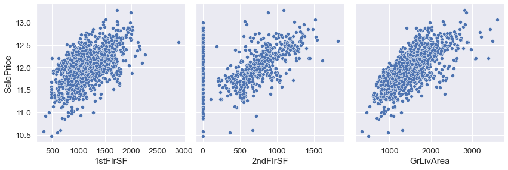

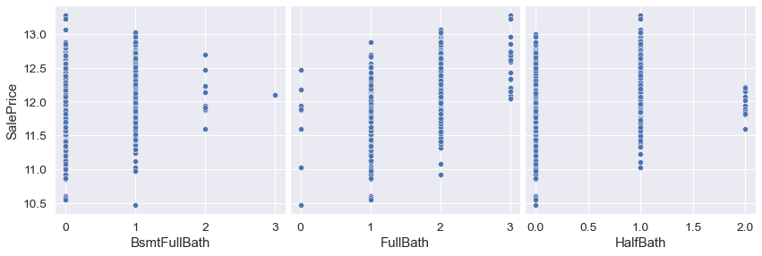

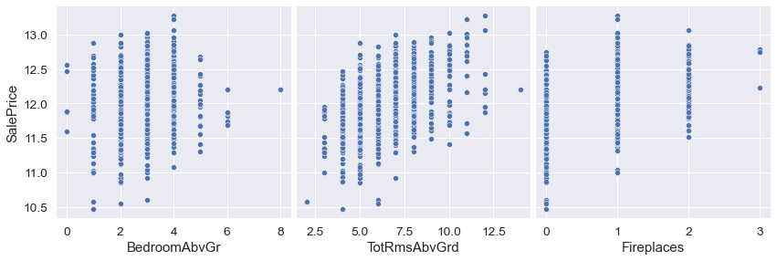

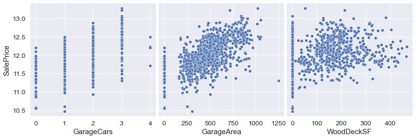

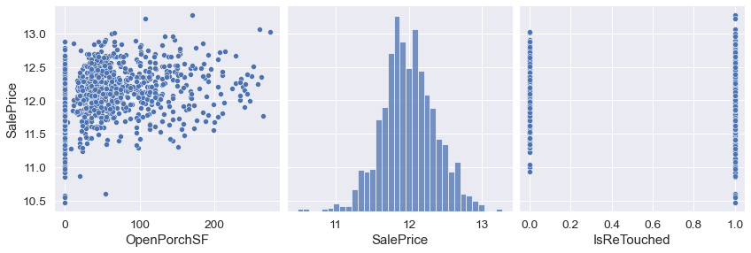

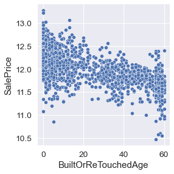

```python
# Check the numerical values using pairplots

plt.figure(figsize=(10,5))
sns.pairplot(houseInfoDF, x_vars=['MSSubClass','LotFrontage','LotArea'], y_vars='SalePrice',height=4, aspect=1,kind='scatter')
sns.pairplot(houseInfoDF, x_vars=['OverallQual', 'OverallCond','MasVnrArea'], y_vars='SalePrice',height=4, aspect=1,kind='scatter')
sns.pairplot(houseInfoDF, x_vars=['BsmtFinSF1', 'BsmtUnfSF','TotalBsmtSF'], y_vars='SalePrice',height=4, aspect=1,kind='scatter')
sns.pairplot(houseInfoDF, x_vars=['1stFlrSF','2ndFlrSF', 'GrLivArea'], y_vars='SalePrice',height=4, aspect=1,kind='scatter')
sns.pairplot(houseInfoDF, x_vars=['BsmtFullBath','FullBath', 'HalfBath'], y_vars='SalePrice',height=4, aspect=1,kind='scatter')
sns.pairplot(houseInfoDF, x_vars=['BedroomAbvGr','TotRmsAbvGrd', 'Fireplaces'], y_vars='SalePrice',height=4, aspect=1,kind='scatter')
sns.pairplot(houseInfoDF, x_vars=['GarageCars','GarageArea', 'WoodDeckSF'], y_vars='SalePrice',height=4, aspect=1,kind='scatter')
sns.pairplot(houseInfoDF, x_vars=['OpenPorchSF','SalePrice', 'IsReTouched'], y_vars='SalePrice',height=4, aspect=1,kind='scatter')
sns.pairplot(houseInfoDF, x_vars=['BuiltOrReTouchedAge'], y_vars='SalePrice',height=4, aspect=1,kind='scatter')
plt.show()
```

Observations :

- 1stFlrSF, GrLivArea seems to be showing correlation towards right
- Increase in Property Age shows a decreasing saleprice trend i.e newer the property, high is the value

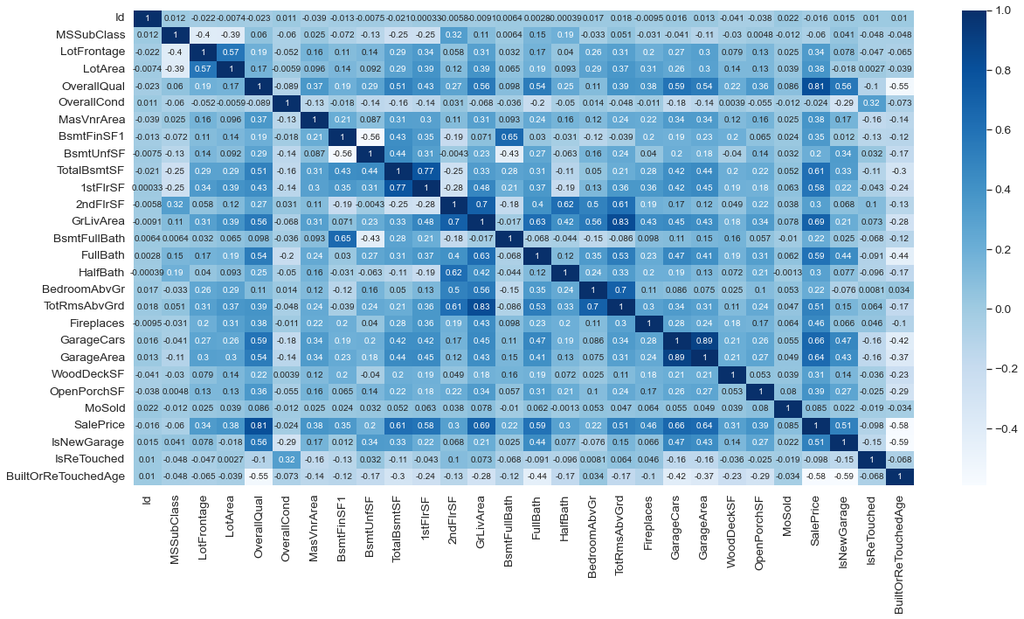

```python
# Check the correlation of numerical columns

correlation_matrix=houseInfoDF.corr()

plt.figure(figsize = (20, 10))
sns.heatmap(correlation_matrix, annot = True, cmap="Blues")
plt.show()
```

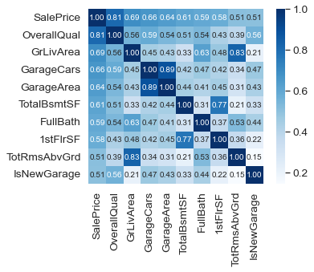

```python
#Selecting top 10

k = 10
cols = correlation_matrix.nlargest(k, 'SalePrice')['SalePrice'].index
cm = np.corrcoef(houseInfoDF[cols].values.T)
sns.set(font_scale=1.25)
hm = sns.heatmap(cm, cbar=True, annot=True, square=True, fmt='.2f', annot_kws={'size': 10}, yticklabels=cols.values, xticklabels=cols.values,cmap="Blues")
plt.show()
```

Following columns which shows high correlation

- TotRmsAbvGrd and GrLivArea
- Garage Area and Garage Cars

We also see below related highly to sales price

- OverallQual - It is obvious that having a good quality house would fetch bigger price
- Grlivarea - More the area of the floor above the ground floor, greater is the price
- Garage cars, garage area, total basement SF, 1st floor SF

```python
# Removing the highly correlated variables .

houseInfoDF.drop(['TotRmsAbvGrd', 'GarageCars'], axis = 1, inplace = True)
```

```python
# Check the shape of the dataframe

houseInfoDF.shape
```

```
(1358, 48)
```

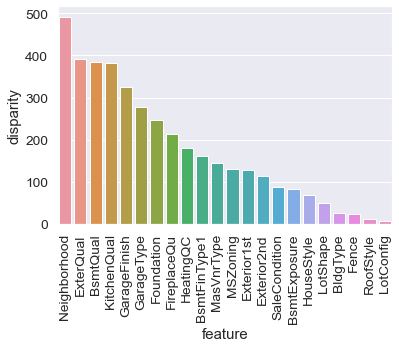

```python
#Quick look on the categorical variables and their disparity over sales . We do this now , before we create dummies or drop .

qualitative = [f for f in houseInfoDF.columns if houseInfoDF.dtypes[f] == 'object']


def anova(frame):
    anv = pd.DataFrame()
    anv['feature'] = qualitative
    pvals = []
    for c in qualitative:
        samples = []
        for cls in frame[c].unique():
            s = frame[frame[c] == cls]['SalePrice'].values
            samples.append(s)
        pval = stats.f_oneway(*samples)[1]
        pvals.append(pval)
    anv['pval'] = pvals
    return anv.sort_values('pval')

a = anova(houseInfoDF)
a['disparity'] = np.log(1./a['pval'].values)
sns.barplot(data=a, x='feature', y='disparity')
x=plt.xticks(rotation=90)
```

From the above chart we can see that some of the majorly influencing variables are -

- Neighbourhood
- ExterQuality
- Basement Quality
- KitchenQuality

## Preparing Data For Modelling

```python
## Drop below columns not needed

houseInfoDF = houseInfoDF.drop(['Id'], axis=1)
houseInfoDF = houseInfoDF.drop(['MoSold'], axis=1)
```

### Dummy Variables

```python
print("######LotShape########")
print(houseInfoDF['LotShape'].value_counts())
print("######ExterQual########")
print(houseInfoDF['ExterQual'].value_counts())
print("######BsmtQual########")
print(houseInfoDF['BsmtQual'].value_counts())
print("######BsmtExposure########")
print(houseInfoDF['BsmtExposure'].value_counts())
print("######BsmtFinType1########")
print(houseInfoDF['BsmtFinType1'].value_counts())
print("######HeatingQC########")
print(houseInfoDF['HeatingQC'].value_counts())
print("######KitchenQual########")
print(houseInfoDF['KitchenQual'].value_counts())
print("######FireplaceQu########")
print(houseInfoDF['FireplaceQu'].value_counts())
print("######BldgType########")
print(houseInfoDF['BldgType'].value_counts())
print("######GarageFinish########")
print(houseInfoDF['GarageFinish'].value_counts())
print("######HouseStyle########")
print(houseInfoDF['HouseStyle'].value_counts())
print("######Fence########")
print(houseInfoDF['Fence'].value_counts())
print("######LotConfig########")
print(houseInfoDF['LotConfig'].value_counts())
print("######MasVnrType########")
print(houseInfoDF['MasVnrType'].value_counts())
print("######SaleCondition########")
print(houseInfoDF['SaleCondition'].value_counts())
```

```
######LotShape########
Reg    880
IR1    441
IR2     29
IR3      8
Name: LotShape, dtype: int64
######ExterQual########
TA    864
Gd    448
Ex     32
Fa     14
Name: ExterQual, dtype: int64
######BsmtQual########
TA      617
Gd      575
Ex       94
None     37
Fa       35
Name: BsmtQual, dtype: int64
######BsmtExposure########
No      906
Av      208
Mn      104
Gd      102
None     38
Name: BsmtExposure, dtype: int64
######BsmtFinType1########
Unf     410
GLQ     377
ALQ     202
BLQ     140
Rec     123
LwQ      69
None     37
Name: BsmtFinType1, dtype: int64
######HeatingQC########
Ex    681
TA    403
Gd    228
Fa     45
```

[output cut: 52 more lines]

```
Name: LotConfig, dtype: int64
######MasVnrType########
None       828
BrkFace    400
Stone      117
BrkCmn      13
Name: MasVnrType, dtype: int64
######SaleCondition########
Normal     1120
Partial     109
Abnorml      95
Family       20
Alloca       10
AdjLand       4
Name: SaleCondition, dtype: int64
```

```python
# Since the values of the following fields are have an implicit order to it, we shall suquence them
# For values which can be ordered, we have given an ordered sequence value
# For values which cannot be ordered, we have categorised them into 0 and 1

houseInfoDF['d_LotShape'] = houseInfoDF['LotShape'].map({'Reg': 3, 'IR1': 2, 'IR2': 1, 'IR3': 0})
houseInfoDF['d_ExterQual'] = houseInfoDF['ExterQual'].map({'Ex': 5, 'Gd': 4, 'TA': 3, 'Fa': 2, 'Po': 1, 'None': 0 })
houseInfoDF['d_BsmtQual'] = houseInfoDF['BsmtQual'].map({'Ex': 5, 'Gd': 4, 'TA': 3, 'Fa': 2, 'Po': 1, 'None': 0})
houseInfoDF['d_BsmtExposure'] = houseInfoDF['BsmtExposure'].map({'Gd': 4, 'Av': 3, 'Mn': 2, 'No': 1, 'None': 0})
houseInfoDF['d_BsmtFinType1'] = houseInfoDF['BsmtFinType1'].map({'GLQ': 6, 'ALQ': 5, 'BLQ': 4, 'Rec': 3, 'LwQ': 2, 'Unf': 1,
                                                                 'None': 0})
houseInfoDF['d_HeatingQC'] = houseInfoDF['HeatingQC'].map({'Ex': 5, 'Gd': 4, 'TA': 3, 'Fa': 2, 'Po': 1, 'None': 0})
houseInfoDF['d_KitchenQual'] = houseInfoDF['KitchenQual'].map({'Ex': 5, 'Gd': 4, 'TA': 3, 'Fa': 2, 'Po': 1, 'None': 0})
houseInfoDF['d_FireplaceQu'] = houseInfoDF['FireplaceQu'].map({'Ex': 5, 'Gd': 4, 'TA': 3, 'Fa': 2, 'Po': 1, 'None': 0})
houseInfoDF['d_GarageFinish'] = houseInfoDF['GarageFinish'].map({'Fin': 3, 'RFn': 2, 'Unf': 1, 'None': 0 })
houseInfoDF['d_BldgType'] = houseInfoDF['BldgType'].map({'Twnhs': 5, 'TwnhsE': 4, 'Duplex': 3, '2fmCon': 2, '1Fam': 1,
                                                                 'None': 0 })
houseInfoDF['d_HouseStyle'] = houseInfoDF['HouseStyle'].map({'SLvl': 8, 'SFoyer': 7, '2.5Fin': 6, '2.5Unf': 5, '2Story': 4,
                                                                 '1.5Fin': 3, '1.5Unf': 2, '1Story': 1, 'None': 0 })
houseInfoDF['d_Fence'] = houseInfoDF['Fence'].map({'GdPrv': 4, 'GdWo': 3, 'MnPrv': 2, 'MnWw': 1, 'None': 0 })
houseInfoDF['d_LotConfig'] = houseInfoDF['LotConfig'].map({'Inside': 5, 'Corner': 4, 'CulDSac': 3, 'FR2': 2, 'FR3': 1,
                                                           'None': 0  })

houseInfoDF['d_MasVnrType'] = houseInfoDF['MasVnrType'].map({'BrkCmn': 1, 'BrkFace': 1, 'CBlock': 1, 'Stone': 1, 'None': 0 })
houseInfoDF['d_SaleCondition'] = houseInfoDF['SaleCondition'].map({'Normal': 1, 'Partial': 1, 'Abnorml': 0, 'Family': 0,
                                                                   'Alloca': 0, 'AdjLand': 0, 'None': 0})

houseInfoDF.head()
```

|  | MSSubClass | MSZoning | LotFrontage | LotArea | LotShape | LotConfig | Neighborhood | BldgType | HouseStyle | OverallQual | ... | d_HeatingQC | d_KitchenQual | d_FireplaceQu | d_GarageFinish | d_BldgType | d_HouseStyle | d_Fence | d_LotConfig | d_MasVnrType | d_SaleCondition |
| --- | --- | --- | --- | --- | --- | --- | --- | --- | --- | --- | --- | --- | --- | --- | --- | --- | --- | --- | --- | --- | --- |
| 0 | 60 | RL | 65.0 | 8450 | Reg | Inside | CollgCr | 1Fam | 2Story | 7 | ... | 5 | 4 | 0 | 2 | 1 | 4 | 0 | 5 | 1 | 1 |
| 1 | 20 | RL | 80.0 | 9600 | Reg | FR2 | Veenker | 1Fam | 1Story | 6 | ... | 5 | 3 | 3 | 2 | 1 | 1 | 0 | 2 | 0 | 1 |
| 2 | 60 | RL | 68.0 | 11250 | IR1 | Inside | CollgCr | 1Fam | 2Story | 7 | ... | 5 | 4 | 3 | 2 | 1 | 4 | 0 | 5 | 1 | 1 |
| 3 | 70 | RL | 60.0 | 9550 | IR1 | Corner | Crawfor | 1Fam | 2Story | 7 | ... | 4 | 4 | 4 | 1 | 1 | 4 | 0 | 4 | 0 | 0 |
| 4 | 60 | RL | 84.0 | 14260 | IR1 | FR2 | NoRidge | 1Fam | 2Story | 8 | ... | 5 | 4 | 3 | 2 | 1 | 4 | 0 | 2 | 1 | 1 |

5 rows × 61 columns

```python
## Creating remaining dummies

d_MSZoning = pd.get_dummies(houseInfoDF['MSZoning'], prefix='MSZoning', drop_first = True)
houseInfoDF = pd.concat([houseInfoDF, d_MSZoning], axis = 1)

# Creating dummies for Neighborhood

d_Neighborhood = pd.get_dummies(houseInfoDF['Neighborhood'], prefix='Neighborhood', drop_first = True)
houseInfoDF = pd.concat([houseInfoDF, d_Neighborhood], axis = 1)

# Creating dummies for RoofStyle

d_RoofStyle = pd.get_dummies(houseInfoDF['RoofStyle'], prefix='RoofStyle', drop_first = True)
houseInfoDF = pd.concat([houseInfoDF, d_RoofStyle], axis = 1)

# Creating dummies for Exterior1st

d_Exterior1st = pd.get_dummies(houseInfoDF['Exterior1st'], prefix='Exterior1st', drop_first = True)
houseInfoDF = pd.concat([houseInfoDF, d_Exterior1st], axis = 1)

# Creating dummies for Exterior2nd

d_Exterior2nd = pd.get_dummies(houseInfoDF['Exterior2nd'], prefix='Exterior2nd', drop_first = True)
houseInfoDF = pd.concat([houseInfoDF, d_Exterior2nd], axis = 1)

# Creating dummies for Foundation

d_Foundation = pd.get_dummies(houseInfoDF['Foundation'], prefix='Foundation', drop_first = True)
houseInfoDF = pd.concat([houseInfoDF, d_Foundation], axis = 1)

# Creating dummies for GarageType

d_GarageType = pd.get_dummies(houseInfoDF['GarageType'], prefix='GarageType', drop_first = True)
houseInfoDF = pd.concat([houseInfoDF, d_GarageType], axis = 1)

houseInfoDF.head()
```

|  | MSSubClass | MSZoning | LotFrontage | LotArea | LotShape | LotConfig | Neighborhood | BldgType | HouseStyle | OverallQual | ... | Foundation_PConc | Foundation_Slab | Foundation_Stone | Foundation_Wood | GarageType_Attchd | GarageType_Basment | GarageType_BuiltIn | GarageType_CarPort | GarageType_Detchd | GarageType_None |
| --- | --- | --- | --- | --- | --- | --- | --- | --- | --- | --- | --- | --- | --- | --- | --- | --- | --- | --- | --- | --- | --- |
| 0 | 60 | RL | 65.0 | 8450 | Reg | Inside | CollgCr | 1Fam | 2Story | 7 | ... | 1 | 0 | 0 | 0 | 1 | 0 | 0 | 0 | 0 | 0 |
| 1 | 20 | RL | 80.0 | 9600 | Reg | FR2 | Veenker | 1Fam | 1Story | 6 | ... | 0 | 0 | 0 | 0 | 1 | 0 | 0 | 0 | 0 | 0 |
| 2 | 60 | RL | 68.0 | 11250 | IR1 | Inside | CollgCr | 1Fam | 2Story | 7 | ... | 1 | 0 | 0 | 0 | 1 | 0 | 0 | 0 | 0 | 0 |
| 3 | 70 | RL | 60.0 | 9550 | IR1 | Corner | Crawfor | 1Fam | 2Story | 7 | ... | 0 | 0 | 0 | 0 | 0 | 0 | 0 | 0 | 1 | 0 |
| 4 | 60 | RL | 84.0 | 14260 | IR1 | FR2 | NoRidge | 1Fam | 2Story | 8 | ... | 1 | 0 | 0 | 0 | 1 | 0 | 0 | 0 | 0 | 0 |

5 rows × 134 columns

```python
# drop the old columns from which the new columns were derived

houseInfoDF = houseInfoDF.drop(['LotShape', 'ExterQual', 'BsmtQual', 'BsmtExposure', 'BsmtFinType1', 'HeatingQC',
                                'KitchenQual', 'FireplaceQu', 'GarageFinish', 'BldgType', 'HouseStyle', 'Fence',
                                'LotConfig', 'MasVnrType', 'SaleCondition'], axis=1)

# drop the below columns as we now have new columns derived from these columns

houseInfoDF = houseInfoDF.drop(['MSZoning', 'Neighborhood', 'RoofStyle', 'Exterior1st', 'Exterior2nd', 'Foundation',
                                'GarageType'], axis=1)

houseInfoDF.head()
```

|  | MSSubClass | LotFrontage | LotArea | OverallQual | OverallCond | MasVnrArea | BsmtFinSF1 | BsmtUnfSF | TotalBsmtSF | 1stFlrSF | ... | Foundation_PConc | Foundation_Slab | Foundation_Stone | Foundation_Wood | GarageType_Attchd | GarageType_Basment | GarageType_BuiltIn | GarageType_CarPort | GarageType_Detchd | GarageType_None |
| --- | --- | --- | --- | --- | --- | --- | --- | --- | --- | --- | --- | --- | --- | --- | --- | --- | --- | --- | --- | --- | --- |
| 0 | 60 | 65.0 | 8450 | 7 | 5 | 196.0 | 706 | 150 | 856 | 856 | ... | 1 | 0 | 0 | 0 | 1 | 0 | 0 | 0 | 0 | 0 |
| 1 | 20 | 80.0 | 9600 | 6 | 8 | 0.0 | 978 | 284 | 1262 | 1262 | ... | 0 | 0 | 0 | 0 | 1 | 0 | 0 | 0 | 0 | 0 |
| 2 | 60 | 68.0 | 11250 | 7 | 5 | 162.0 | 486 | 434 | 920 | 920 | ... | 1 | 0 | 0 | 0 | 1 | 0 | 0 | 0 | 0 | 0 |
| 3 | 70 | 60.0 | 9550 | 7 | 5 | 0.0 | 216 | 540 | 756 | 961 | ... | 0 | 0 | 0 | 0 | 0 | 0 | 0 | 0 | 1 | 0 |
| 4 | 60 | 84.0 | 14260 | 8 | 5 | 350.0 | 655 | 490 | 1145 | 1145 | ... | 1 | 0 | 0 | 0 | 1 | 0 | 0 | 0 | 0 | 0 |

5 rows × 112 columns

```python
## We verify if all are numeric

houseInfoDF.info()
```

```
<class 'pandas.core.frame.DataFrame'>
Int64Index: 1358 entries, 0 to 1458
Columns: 112 entries, MSSubClass to GarageType_None
dtypes: float64(3), int64(36), uint8(73)
memory usage: 553.5 KB
```

## Test Train Model Split and Scaling

```python
# Putting all feature variable to X
X = houseInfoDF.drop(['SalePrice'], axis=1)
X.head()
```

|  | MSSubClass | LotFrontage | LotArea | OverallQual | OverallCond | MasVnrArea | BsmtFinSF1 | BsmtUnfSF | TotalBsmtSF | 1stFlrSF | ... | Foundation_PConc | Foundation_Slab | Foundation_Stone | Foundation_Wood | GarageType_Attchd | GarageType_Basment | GarageType_BuiltIn | GarageType_CarPort | GarageType_Detchd | GarageType_None |
| --- | --- | --- | --- | --- | --- | --- | --- | --- | --- | --- | --- | --- | --- | --- | --- | --- | --- | --- | --- | --- | --- |
| 0 | 60 | 65.0 | 8450 | 7 | 5 | 196.0 | 706 | 150 | 856 | 856 | ... | 1 | 0 | 0 | 0 | 1 | 0 | 0 | 0 | 0 | 0 |
| 1 | 20 | 80.0 | 9600 | 6 | 8 | 0.0 | 978 | 284 | 1262 | 1262 | ... | 0 | 0 | 0 | 0 | 1 | 0 | 0 | 0 | 0 | 0 |
| 2 | 60 | 68.0 | 11250 | 7 | 5 | 162.0 | 486 | 434 | 920 | 920 | ... | 1 | 0 | 0 | 0 | 1 | 0 | 0 | 0 | 0 | 0 |
| 3 | 70 | 60.0 | 9550 | 7 | 5 | 0.0 | 216 | 540 | 756 | 961 | ... | 0 | 0 | 0 | 0 | 0 | 0 | 0 | 0 | 1 | 0 |
| 4 | 60 | 84.0 | 14260 | 8 | 5 | 350.0 | 655 | 490 | 1145 | 1145 | ... | 1 | 0 | 0 | 0 | 1 | 0 | 0 | 0 | 0 | 0 |

5 rows × 111 columns

```python
# Putting response variable to y
y = houseInfoDF['SalePrice']
y.head()
```

```
0    12.247699
1    12.109016
2    12.317171
3    11.849405
4    12.429220
Name: SalePrice, dtype: float64
```

```python
##Verifying the columns

print(list(X.columns))
```

```
['MSSubClass', 'LotFrontage', 'LotArea', 'OverallQual', 'OverallCond', 'MasVnrArea', 'BsmtFinSF1', 'BsmtUnfSF', 'TotalBsmtSF', '1stFlrSF', '2ndFlrSF', 'GrLivArea', 'BsmtFullBath', 'FullBath', 'HalfBath', 'BedroomAbvGr', 'Fireplaces', 'GarageArea', 'WoodDeckSF', 'OpenPorchSF', 'IsNewGarage', 'IsReTou…
```

```python
# scaling the features

#from sklearn.preprocessing import StandardScaler
#scaler = StandardScaler()
#scaler.fit_transform(X)

# scaling the features

from sklearn.preprocessing import scale

# storing column names in cols
# scaling (the dataframe is converted to a numpy array)

cols = X.columns
X = pd.DataFrame(scale(X))
X.columns = cols
X.columns
```

```
Index(['MSSubClass', 'LotFrontage', 'LotArea', 'OverallQual', 'OverallCond',
       'MasVnrArea', 'BsmtFinSF1', 'BsmtUnfSF', 'TotalBsmtSF', '1stFlrSF',
       ...
       'Foundation_PConc', 'Foundation_Slab', 'Foundation_Stone',
       'Foundation_Wood', 'GarageType_Attchd', 'GarageType_Basment',
       'GarageType_BuiltIn', 'GarageType_CarPort', 'GarageType_Detchd',
       'GarageType_None'],
      dtype='object', length=111)
```

```python
# split into train and test
from sklearn.model_selection import train_test_split
np.random.seed(0)
X_train, X_test, y_train, y_test = train_test_split(X, y,
                                                    train_size=0.7,
                                                    test_size = 0.3, random_state=100)
```

### Recursive feature elimination (RFE)

Since there are around 100+ features, we will use RFE to get the best 50 features out of all features and use the new features for further analysis

```python
# Running RFE with the output number of the variable equal to 50

lm = LinearRegression()
lm.fit(X_train, y_train)

# running RFE
rfe = RFE(lm, 50)
rfe = rfe.fit(X_train, y_train)
```

```python
# Assign the columns selected by RFE to cols

col = X_train.columns[rfe.support_]

# assign the 50 features selected using RFE to a dataframe and view them

temp_df = pd.DataFrame(list(zip(X_train.columns,rfe.support_,rfe.ranking_)), columns=['Variable', 'rfe_support', 'rfe_ranking'])
temp_df = temp_df.loc[temp_df['rfe_support'] == True]
temp_df.reset_index(drop=True, inplace=True)
temp_df
```

|  | Variable | rfe_support | rfe_ranking |
| --- | --- | --- | --- |
| 0 | LotFrontage | True | 1 |
| 1 | LotArea | True | 1 |
| 2 | OverallQual | True | 1 |
| 3 | OverallCond | True | 1 |
| 4 | BsmtFinSF1 | True | 1 |
| 5 | TotalBsmtSF | True | 1 |
| 6 | 1stFlrSF | True | 1 |
| 7 | 2ndFlrSF | True | 1 |
| 8 | GrLivArea | True | 1 |
| 9 | BsmtFullBath | True | 1 |
| 10 | HalfBath | True | 1 |
| 11 | Fireplaces | True | 1 |
| 12 | GarageArea | True | 1 |
| 13 | WoodDeckSF | True | 1 |
| 14 | IsNewGarage | True | 1 |
| 15 | IsReTouched | True | 1 |
| 16 | BuiltOrReTouchedAge | True | 1 |
| 17 | d_BsmtQual | True | 1 |
| 18 | d_BsmtExposure | True | 1 |
| 19 | d_HeatingQC | True | 1 |
| 20 | d_KitchenQual | True | 1 |
| 21 | d_GarageFinish | True | 1 |
| 22 | d_BldgType | True | 1 |
| 23 | d_SaleCondition | True | 1 |
| 24 | MSZoning_FV | True | 1 |
| 25 | MSZoning_RH | True | 1 |
| 26 | MSZoning_RL | True | 1 |
| 27 | MSZoning_RM | True | 1 |
| 28 | Neighborhood_Crawfor | True | 1 |
| 29 | Neighborhood_MeadowV | True | 1 |
| 30 | Neighborhood_NridgHt | True | 1 |
| 31 | Neighborhood_OldTown | True | 1 |
| 32 | Neighborhood_StoneBr | True | 1 |
| 33 | RoofStyle_Gable | True | 1 |
| 34 | RoofStyle_Gambrel | True | 1 |
| 35 | RoofStyle_Hip | True | 1 |
| 36 | Exterior1st_BrkFace | True | 1 |
| 37 | Exterior1st_CemntBd | True | 1 |
| 38 | Exterior1st_VinylSd | True | 1 |
| 39 | Exterior1st_Wd Sdng | True | 1 |
| 40 | Exterior2nd_CmentBd | True | 1 |
| 41 | Exterior2nd_VinylSd | True | 1 |
| 42 | Exterior2nd_Wd Sdng | True | 1 |
| 43 | Foundation_CBlock | True | 1 |
| 44 | Foundation_PConc | True | 1 |
| 45 | Foundation_Slab | True | 1 |
| 46 | Foundation_Stone | True | 1 |
| 47 | GarageType_Attchd | True | 1 |
| 48 | GarageType_BuiltIn | True | 1 |
| 49 | GarageType_Detchd | True | 1 |

```python
# Assign the 50 columns to X_train_rfe
X_train_rfe = X_train[col]
```

```python
# Associate the new 50 columns to X_train and X_test for further analysis

X_train = X_train_rfe[X_train_rfe.columns]
X_test =  X_test[X_train.columns]
```

# Model Building and Evaluation after Regularisation

# Ridge

```python
# list of alphas

params = {'alpha': [0.0001, 0.001, 0.01, 0.1, 0.2, 0.3, 0.4, 0.5, 0.6, 0.7, 0.8, 0.9, 1.0, 2.0, 3.0, 4.0, 5.0, 6.0, 7.0, 8.0,
                    9.0, 10.0, 20, 50, 100, 500, 1000 ]}

ridge = Ridge()

# cross validation

folds = 5
ridge_model_cv = GridSearchCV(estimator = ridge,
                        param_grid = params,
                        scoring= 'neg_mean_absolute_error',
                        cv = folds,
                        return_train_score=True,
                        verbose = 1)
ridge_model_cv.fit(X_train, y_train)
```

```
Fitting 5 folds for each of 27 candidates, totalling 135 fits
```

```
GridSearchCV(cv=5, estimator=Ridge(),
             param_grid={'alpha': [0.0001, 0.001, 0.01, 0.1, 0.2, 0.3, 0.4, 0.5,
                                   0.6, 0.7, 0.8, 0.9, 1.0, 2.0, 3.0, 4.0, 5.0,
                                   6.0, 7.0, 8.0, 9.0, 10.0, 20, 50, 100, 500,
                                   1000]},
             return_train_score=True, scoring='neg_mean_absolute_error',
             verbose=1)
```

```python
#checking the value of optimum number of parameters
print(ridge_model_cv.best_params_)
print(ridge_model_cv.best_score_)
```

```
{'alpha': 0.4}
-0.07975106389420768
```

```python
# display the mean scores

ridge_cv_results = pd.DataFrame(ridge_model_cv.cv_results_)
ridge_cv_results = ridge_cv_results[ridge_cv_results['param_alpha']<=500]
ridge_cv_results[['param_alpha', 'mean_train_score', 'mean_test_score', 'rank_test_score']].sort_values(by = ['rank_test_score'])
```

|  | param_alpha | mean_train_score | mean_test_score | rank_test_score |
| --- | --- | --- | --- | --- |
| 6 | 0.4 | -0.074804 | -0.079751 | 1 |
| 5 | 0.3 | -0.074808 | -0.079753 | 2 |
| 7 | 0.5 | -0.074801 | -0.079753 | 3 |
| 8 | 0.6 | -0.074799 | -0.079756 | 4 |
| 4 | 0.2 | -0.074812 | -0.079758 | 5 |
| 9 | 0.7 | -0.074797 | -0.079758 | 6 |
| 10 | 0.8 | -0.074797 | -0.079761 | 7 |
| 3 | 0.1 | -0.074817 | -0.079765 | 8 |
| 11 | 0.9 | -0.074798 | -0.079767 | 9 |
| 12 | 1.0 | -0.074799 | -0.079773 | 10 |
| 2 | 0.01 | -0.074823 | -0.079776 | 11 |
| 1 | 0.001 | -0.074824 | -0.079777 | 12 |
| 0 | 0.0001 | -0.074824 | -0.079777 | 13 |
| 13 | 2.0 | -0.074846 | -0.079832 | 14 |
| 14 | 3.0 | -0.074926 | -0.079885 | 15 |
| 15 | 4.0 | -0.075003 | -0.079927 | 16 |
| 16 | 5.0 | -0.075069 | -0.079967 | 17 |
| 17 | 6.0 | -0.075128 | -0.080011 | 18 |
| 18 | 7.0 | -0.075180 | -0.080051 | 19 |
| 19 | 8.0 | -0.075228 | -0.080084 | 20 |
| 20 | 9.0 | -0.075272 | -0.080112 | 21 |
| 21 | 10.0 | -0.075311 | -0.080136 | 22 |
| 22 | 20 | -0.075582 | -0.080287 | 23 |
| 23 | 50 | -0.076039 | -0.080391 | 24 |
| 24 | 100 | -0.076678 | -0.080611 | 25 |
| 25 | 500 | -0.083082 | -0.085644 | 26 |

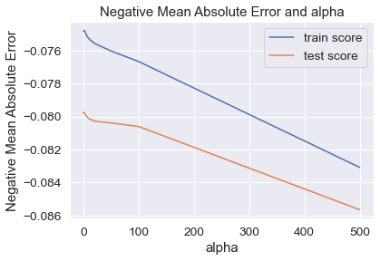

```python
# plotting mean test and train scoes with alpha

ridge_cv_results['param_alpha'] = ridge_cv_results['param_alpha'].astype('int32')

# plotting

plt.plot(ridge_cv_results['param_alpha'], ridge_cv_results['mean_train_score'])
plt.plot(ridge_cv_results['param_alpha'], ridge_cv_results['mean_test_score'])
plt.xlabel('alpha')
plt.ylabel('Negative Mean Absolute Error')
plt.title("Negative Mean Absolute Error and alpha")
plt.legend(['train score', 'test score'], loc='upper right')
plt.show()
```

```python
# get the best estimator for lambda

ridge_model_cv.best_estimator_
```

```
Ridge(alpha=0.4)
```

```python
# check the coefficient values with lambda

alpha = 0.4
ridge = Ridge(alpha=alpha)

ridge.fit(X_train, y_train)
ridge.coef_
```

```
array([ 0.00968331,  0.0151916 ,  0.0743886 ,  0.03566075,  0.02667861,
        0.03862125, -0.01095956, -0.01961225,  0.12940811,  0.00987804,
        0.01145701,  0.01522013,  0.03661995,  0.00977932,  0.01168005,
       -0.01999613, -0.03156894,  0.01679104,  0.01263448,  0.0175681 ,
        0.01572202,  0.01339077, -0.01603585,  0.01583473,  0.08289025,
        0.03331208,  0.13892831,  0.1093277 ,  0.02076441, -0.01524421,
        0.02171439, -0.01820579,  0.01274223,  0.01848029,  0.00970501,
        0.01512535,  0.01217247, -0.03394552, -0.04115995, -0.02167225,
        0.03695637,  0.03178688,  0.01261161,  0.02010581,  0.04110906,
        0.01304767,  0.01075165,  0.03356982,  0.01703234,  0.02007593])
```

```python
#lets predict the R-squared value of test and train data
from sklearn.metrics import r2_score

y_train_pred = ridge.predict(X_train)
print(r2_score(y_true=y_train, y_pred=y_train_pred))

y_test_pred = ridge.predict(X_test)
print(r2_score(y_true=y_test, y_pred=y_test_pred))
```

```
0.9230200865046913
0.8922983738820501
```

```python
# Check the mean squared error
print('MSE:',mean_squared_error(y_test, ridge.predict(X_test)))
print('RMSE :', np.sqrt(mean_squared_error(y_test, y_test_pred)))
```

```
MSE: 0.015888159710745184
RMSE : 0.1260482435845307
```

```python
# Put the Features and coefficienst in a dataframe

ridge_df = pd.DataFrame({'Features':X_train.columns, 'Coefficient':ridge.coef_.round(4)})
ridge_df.reset_index(drop=True, inplace=True)
ridge_df.sort_values(by=['Coefficient'], ascending = False)
```

|  | Features | Coefficient |
| --- | --- | --- |
| 26 | MSZoning_RL | 0.1389 |
| 8 | GrLivArea | 0.1294 |
| 27 | MSZoning_RM | 0.1093 |
| 24 | MSZoning_FV | 0.0829 |
| 2 | OverallQual | 0.0744 |
| 44 | Foundation_PConc | 0.0411 |
| 5 | TotalBsmtSF | 0.0386 |
| 40 | Exterior2nd_CmentBd | 0.0370 |
| 12 | GarageArea | 0.0366 |
| 3 | OverallCond | 0.0357 |
| 47 | GarageType_Attchd | 0.0336 |
| 25 | MSZoning_RH | 0.0333 |
| 41 | Exterior2nd_VinylSd | 0.0318 |
| 4 | BsmtFinSF1 | 0.0267 |
| 30 | Neighborhood_NridgHt | 0.0217 |
| 28 | Neighborhood_Crawfor | 0.0208 |
| 43 | Foundation_CBlock | 0.0201 |
| 49 | GarageType_Detchd | 0.0201 |
| 33 | RoofStyle_Gable | 0.0185 |
| 19 | d_HeatingQC | 0.0176 |
| 48 | GarageType_BuiltIn | 0.0170 |
| 17 | d_BsmtQual | 0.0168 |
| 23 | d_SaleCondition | 0.0158 |
| 20 | d_KitchenQual | 0.0157 |
| 1 | LotArea | 0.0152 |
| 11 | Fireplaces | 0.0152 |
| 35 | RoofStyle_Hip | 0.0151 |
| 21 | d_GarageFinish | 0.0134 |
| 45 | Foundation_Slab | 0.0130 |
| 32 | Neighborhood_StoneBr | 0.0127 |
| 18 | d_BsmtExposure | 0.0126 |
| 42 | Exterior2nd_Wd Sdng | 0.0126 |
| 36 | Exterior1st_BrkFace | 0.0122 |
| 14 | IsNewGarage | 0.0117 |
| 10 | HalfBath | 0.0115 |
| 46 | Foundation_Stone | 0.0108 |
| 9 | BsmtFullBath | 0.0099 |
| 13 | WoodDeckSF | 0.0098 |
| 34 | RoofStyle_Gambrel | 0.0097 |
| 0 | LotFrontage | 0.0097 |
| 6 | 1stFlrSF | -0.0110 |
| 29 | Neighborhood_MeadowV | -0.0152 |
| 22 | d_BldgType | -0.0160 |
| 31 | Neighborhood_OldTown | -0.0182 |
| 7 | 2ndFlrSF | -0.0196 |
| 15 | IsReTouched | -0.0200 |
| 39 | Exterior1st_Wd Sdng | -0.0217 |
| 16 | BuiltOrReTouchedAge | -0.0316 |
| 37 | Exterior1st_CemntBd | -0.0339 |
| 38 | Exterior1st_VinylSd | -0.0412 |

```python
# Assign the Features and their coefficient values to a dictionary

ridge_coeff_dict = dict(pd.Series(ridge.coef_.round(4), index = X_train.columns))
ridge_coeff_dict
```

```
{'LotFrontage': 0.0097,
 'LotArea': 0.0152,
 'OverallQual': 0.0744,
 'OverallCond': 0.0357,
 'BsmtFinSF1': 0.0267,
 'TotalBsmtSF': 0.0386,
 '1stFlrSF': -0.011,
 '2ndFlrSF': -0.0196,
 'GrLivArea': 0.1294,
 'BsmtFullBath': 0.0099,
 'HalfBath': 0.0115,
 'Fireplaces': 0.0152,
 'GarageArea': 0.0366,
 'WoodDeckSF': 0.0098,
 'IsNewGarage': 0.0117,
 'IsReTouched': -0.02,
 'BuiltOrReTouchedAge': -0.0316,
 'd_BsmtQual': 0.0168,
 'd_BsmtExposure': 0.0126,
 'd_HeatingQC': 0.0176,
 'd_KitchenQual': 0.0157,
 'd_GarageFinish': 0.0134,
 'd_BldgType': -0.016,
 'd_SaleCondition': 0.0158,
 'MSZoning_FV': 0.0829,
 'MSZoning_RH': 0.0333,
 'MSZoning_RL': 0.1389,
 'MSZoning_RM': 0.1093,
 'Neighborhood_Crawfor': 0.0208,
 'Neighborhood_MeadowV': -0.0152,
 'Neighborhood_NridgHt': 0.0217,
 'Neighborhood_OldTown': -0.0182,
 'Neighborhood_StoneBr': 0.0127,
 'RoofStyle_Gable': 0.0185,
 'RoofStyle_Gambrel': 0.0097,
 'RoofStyle_Hip': 0.0151,
 'Exterior1st_BrkFace': 0.0122,
 'Exterior1st_CemntBd': -0.0339,
 'Exterior1st_VinylSd': -0.0412,
 'Exterior1st_Wd Sdng': -0.0217,
 'Exterior2nd_CmentBd': 0.037,
 'Exterior2nd_VinylSd': 0.0318,
 'Exterior2nd_Wd Sdng': 0.0126,
 'Foundation_CBlock': 0.0201,
 'Foundation_PConc': 0.0411,
 'Foundation_Slab': 0.013,
 'Foundation_Stone': 0.0108,
 'GarageType_Attchd': 0.0336,
 'GarageType_BuiltIn': 0.017,
 'GarageType_Detchd': 0.0201}
```

## RFE again to Minimize the features and plot a graph for ease of Buisness

```python
# Do an RFE to minimise the features to 15
X_train_ridge = X_train[ridge_df.Features]

lm = LinearRegression()
lm.fit(X_train_ridge, y_train)

# running RFE
rfe = RFE(lm, 15)
rfe = rfe.fit(X_train_ridge, y_train)
```

```python
# Method to get the coefficient values

def find(x):
    return ridge_coeff_dict[x]

# Assign top 10 features to a temp dataframe for further display in the bar plot

temp1_df = pd.DataFrame(list(zip( X_train_ridge.columns, rfe.support_, rfe.ranking_)), columns=['Features', 'rfe_support', 'rfe_ranking'])
temp1_df = temp1_df.loc[temp1_df['rfe_support'] == True]
temp1_df.reset_index(drop=True, inplace=True)

temp1_df['Coefficient'] = temp1_df['Features'].apply(find)
temp1_df = temp1_df.sort_values(by=['Coefficient'], ascending=False)
temp1_df = temp1_df.head(15)
temp1_df
```

|  | Features | rfe_support | rfe_ranking | Coefficient |
| --- | --- | --- | --- | --- |
| 9 | MSZoning_RL | True | 1 | 0.1389 |
| 4 | GrLivArea | True | 1 | 0.1294 |
| 8 | MSZoning_FV | True | 1 | 0.0829 |
| 0 | OverallQual | True | 1 | 0.0744 |
| 14 | Foundation_PConc | True | 1 | 0.0411 |
| 3 | TotalBsmtSF | True | 1 | 0.0386 |
| 12 | Exterior2nd_CmentBd | True | 1 | 0.0370 |
| 5 | GarageArea | True | 1 | 0.0366 |
| 1 | OverallCond | True | 1 | 0.0357 |
| 13 | Exterior2nd_VinylSd | True | 1 | 0.0318 |
| 2 | BsmtFinSF1 | True | 1 | 0.0267 |
| 7 | d_GarageFinish | True | 1 | 0.0134 |
| 6 | BuiltOrReTouchedAge | True | 1 | -0.0316 |
| 10 | Exterior1st_CemntBd | True | 1 | -0.0339 |
| 11 | Exterior1st_VinylSd | True | 1 | -0.0412 |

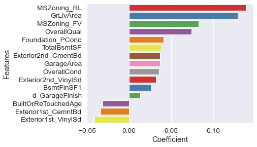

```python
# bar plot to determine the variables that would affect pricing most using ridge regression

plt.figure(figsize=(20,20))
plt.subplot(4,3,1)
sns.barplot(y = 'Features', x='Coefficient', palette='Set1', data = temp1_df)
plt.show()
```

# Lasso

```python
lasso = Lasso()

# list of alphas

params = {'alpha': [0.0001, 0.0002, 0.0003, 0.0004, 0.0005, 0.001, 0.002, 0.003, 0.004, 0.005, 0.01]}

# cross validation

folds = 5
lasso_model_cv = GridSearchCV(estimator = lasso,
                        param_grid = params,
                        scoring= 'neg_mean_absolute_error',
                        cv = folds,
                        return_train_score=True,
                        verbose = 1)

lasso_model_cv.fit(X_train, y_train)
```

```
Fitting 5 folds for each of 11 candidates, totalling 55 fits
```

```
GridSearchCV(cv=5, estimator=Lasso(),
             param_grid={'alpha': [0.0001, 0.0002, 0.0003, 0.0004, 0.0005,
                                   0.001, 0.002, 0.003, 0.004, 0.005, 0.01]},
             return_train_score=True, scoring='neg_mean_absolute_error',
             verbose=1)
```

```python
# display the mean scores

lasso_cv_results = pd.DataFrame(lasso_model_cv.cv_results_)
lasso_cv_results[['param_alpha', 'mean_train_score', 'mean_test_score', 'rank_test_score']].sort_values(by = ['rank_test_score'])
```

|  | param_alpha | mean_train_score | mean_test_score | rank_test_score |
| --- | --- | --- | --- | --- |
| 0 | 0.0001 | -0.074786 | -0.079747 | 1 |
| 1 | 0.0002 | -0.074839 | -0.079852 | 2 |
| 2 | 0.0003 | -0.074944 | -0.080003 | 3 |
| 3 | 0.0004 | -0.075085 | -0.080150 | 4 |
| 4 | 0.0005 | -0.075245 | -0.080304 | 5 |
| 5 | 0.001 | -0.076039 | -0.080960 | 6 |
| 6 | 0.002 | -0.076898 | -0.081182 | 7 |
| 7 | 0.003 | -0.077271 | -0.081352 | 8 |
| 8 | 0.004 | -0.077681 | -0.081535 | 9 |
| 9 | 0.005 | -0.078185 | -0.082023 | 10 |
| 10 | 0.01 | -0.082240 | -0.085642 | 11 |

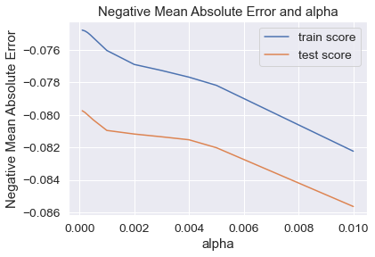

```python
# plotting mean test and train scoes with alpha

lasso_cv_results['param_alpha'] = lasso_cv_results['param_alpha'].astype('float64')

# plotting

plt.plot(lasso_cv_results['param_alpha'], lasso_cv_results['mean_train_score'])
plt.plot(lasso_cv_results['param_alpha'], lasso_cv_results['mean_test_score'])
plt.xlabel('alpha')
plt.ylabel('Negative Mean Absolute Error')

plt.title("Negative Mean Absolute Error and alpha")
plt.legend(['train score', 'test score'], loc='upper right')
plt.show()
```

```python
# get the best estimator for lambda

lasso_model_cv.best_estimator_
```

```
Lasso(alpha=0.0001)
```

```python
# check the coefficient values with lambda

alpha = 0.0001

lasso = Lasso(alpha=alpha)

lasso.fit(X_train, y_train)

# prediction on the test set(Using R2)
y_train_pred = lasso.predict(X_train)
print(r2_score(y_true=y_train, y_pred=y_train_pred))
y_test_pred = lasso.predict(X_test)
print(r2_score(y_true=y_test, y_pred=y_test_pred))

lasso.coef_
```

```
0.9229465515747793
0.8929962398579729
```

```
array([ 0.00967029,  0.01484363,  0.07478122,  0.03580601,  0.0267742 ,
        0.03881617,  0.        , -0.00574811,  0.11460965,  0.00967913,
        0.01103221,  0.01523358,  0.03657403,  0.00973032,  0.01155329,
       -0.01997372, -0.03164073,  0.01657425,  0.01250434,  0.01739894,
        0.01581738,  0.0135709 , -0.01589827,  0.01596712,  0.07959925,
        0.03161367,  0.1326004 ,  0.10325919,  0.02057882, -0.01504666,
        0.0213994 , -0.01814199,  0.01246114,  0.01555321,  0.00884222,
        0.01233484,  0.01216254, -0.02758914, -0.03744655, -0.02080667,
        0.03071621,  0.02820047,  0.01180668,  0.01901211,  0.04017168,
        0.01258369,  0.00994925,  0.03251936,  0.0163249 ,  0.01913427])
```

```python
# Check the mean squared error

print('MSE :', (mean_squared_error(y_test, y_test_pred)))
print('RMSE :', np.sqrt(mean_squared_error(y_test, y_test_pred)))
```

```
MSE : 0.01578521041943166
RMSE : 0.125639207333665
```

```python
# Put the shortlisted Features and coefficienst in a dataframe and sort them

lasso_df = pd.DataFrame({'Features':X_train.columns, 'Coefficient':lasso.coef_.round(4)})
lasso_df = lasso_df[lasso_df['Coefficient'] != 0.00]
lasso_df.reset_index(drop=True, inplace=True)
lasso_df.sort_values(by=['Coefficient'], ascending = False)
```

|  | Features | Coefficient |
| --- | --- | --- |
| 25 | MSZoning_RL | 0.1326 |
| 7 | GrLivArea | 0.1146 |
| 26 | MSZoning_RM | 0.1033 |
| 23 | MSZoning_FV | 0.0796 |
| 2 | OverallQual | 0.0748 |
| 43 | Foundation_PConc | 0.0402 |
| 5 | TotalBsmtSF | 0.0388 |
| 11 | GarageArea | 0.0366 |
| 3 | OverallCond | 0.0358 |
| 46 | GarageType_Attchd | 0.0325 |
| 24 | MSZoning_RH | 0.0316 |
| 39 | Exterior2nd_CmentBd | 0.0307 |
| 40 | Exterior2nd_VinylSd | 0.0282 |
| 4 | BsmtFinSF1 | 0.0268 |
| 29 | Neighborhood_NridgHt | 0.0214 |
| 27 | Neighborhood_Crawfor | 0.0206 |
| 48 | GarageType_Detchd | 0.0191 |
| 42 | Foundation_CBlock | 0.0190 |
| 18 | d_HeatingQC | 0.0174 |
| 16 | d_BsmtQual | 0.0166 |
| 47 | GarageType_BuiltIn | 0.0163 |
| 22 | d_SaleCondition | 0.0160 |
| 19 | d_KitchenQual | 0.0158 |
| 32 | RoofStyle_Gable | 0.0156 |
| 10 | Fireplaces | 0.0152 |
| 1 | LotArea | 0.0148 |
| 20 | d_GarageFinish | 0.0136 |
| 44 | Foundation_Slab | 0.0126 |
| 17 | d_BsmtExposure | 0.0125 |
| 31 | Neighborhood_StoneBr | 0.0125 |
| 34 | RoofStyle_Hip | 0.0123 |
| 35 | Exterior1st_BrkFace | 0.0122 |
| 41 | Exterior2nd_Wd Sdng | 0.0118 |
| 13 | IsNewGarage | 0.0116 |
| 9 | HalfBath | 0.0110 |
| 45 | Foundation_Stone | 0.0099 |
| 8 | BsmtFullBath | 0.0097 |
| 0 | LotFrontage | 0.0097 |
| 12 | WoodDeckSF | 0.0097 |
| 33 | RoofStyle_Gambrel | 0.0088 |
| 6 | 2ndFlrSF | -0.0057 |
| 28 | Neighborhood_MeadowV | -0.0150 |
| 21 | d_BldgType | -0.0159 |
| 30 | Neighborhood_OldTown | -0.0181 |
| 14 | IsReTouched | -0.0200 |
| 38 | Exterior1st_Wd Sdng | -0.0208 |
| 36 | Exterior1st_CemntBd | -0.0276 |
| 15 | BuiltOrReTouchedAge | -0.0316 |
| 37 | Exterior1st_VinylSd | -0.0374 |

```python
# Put the Features and Coefficients in dictionary

lasso_coeff_dict = dict(pd.Series(lasso.coef_, index = X_train.columns))
lasso_coeff_dict
```

```
{'LotFrontage': 0.009670286160727432,
 'LotArea': 0.014843634019959672,
 'OverallQual': 0.07478121524425305,
 'OverallCond': 0.03580600838359957,
 'BsmtFinSF1': 0.02677419960494639,
 'TotalBsmtSF': 0.03881617022769977,
 '1stFlrSF': 0.0,
 '2ndFlrSF': -0.005748110664958964,
 'GrLivArea': 0.11460964836961177,
 'BsmtFullBath': 0.009679133603261553,
 'HalfBath': 0.01103220995048388,
 'Fireplaces': 0.015233576313044467,
 'GarageArea': 0.03657402539535543,
 'WoodDeckSF': 0.00973031931686793,
 'IsNewGarage': 0.011553292368615492,
 'IsReTouched': -0.01997372255932995,
 'BuiltOrReTouchedAge': -0.0316407322214055,
 'd_BsmtQual': 0.0165742496564749,
 'd_BsmtExposure': 0.01250434124601429,
 'd_HeatingQC': 0.017398935837071305,
 'd_KitchenQual': 0.015817382431532776,
 'd_GarageFinish': 0.013570904243555665,
 'd_BldgType': -0.015898272243879515,
 'd_SaleCondition': 0.015967121996521727,
 'MSZoning_FV': 0.07959924600969533,
 'MSZoning_RH': 0.031613673999175126,
 'MSZoning_RL': 0.13260040450522273,
 'MSZoning_RM': 0.1032591928078554,
 'Neighborhood_Crawfor': 0.020578816285098778,
 'Neighborhood_MeadowV': -0.015046662593554026,
 'Neighborhood_NridgHt': 0.021399401114756304,
 'Neighborhood_OldTown': -0.01814198744098131,
 'Neighborhood_StoneBr': 0.012461141873856753,
 'RoofStyle_Gable': 0.015553206646688328,
 'RoofStyle_Gambrel': 0.008842224138618293,
 'RoofStyle_Hip': 0.012334841149409576,
 'Exterior1st_BrkFace': 0.012162537229000597,
 'Exterior1st_CemntBd': -0.027589135475996136,
 'Exterior1st_VinylSd': -0.03744655026167226,
 'Exterior1st_Wd Sdng': -0.020806669141066186,
 'Exterior2nd_CmentBd': 0.0307162074765703,
 'Exterior2nd_VinylSd': 0.028200470486097754,
 'Exterior2nd_Wd Sdng': 0.011806683931714624,
 'Foundation_CBlock': 0.019012110232493485,
 'Foundation_PConc': 0.04017167708501609,
 'Foundation_Slab': 0.01258368930763979,
 'Foundation_Stone': 0.009949250884769726,
 'GarageType_Attchd': 0.032519361733141086,
 'GarageType_BuiltIn': 0.01632489963564092,
 'GarageType_Detchd': 0.01913426924167871}
```

## RFE again to Minimize the features and plot a graph for ease of explaning to Buisness

```python
# Do an RFE to minimise the features to 15 and plot graph

X_train_lasso = X_train[lasso_df.Features]

lm = LinearRegression()
lm.fit(X_train_lasso, y_train)

# running RFE

rfe = RFE(lm, 15)
rfe = rfe.fit(X_train_lasso, y_train)
```

```python
# Method to get the coefficient values

def find(x):
    return lasso_coeff_dict[x]

# Assign top 10 features to a temp dataframe for further display in the bar plot

temp2_df = pd.DataFrame(list(zip( X_train_lasso.columns, rfe.support_, rfe.ranking_)), columns=['Features', 'rfe_support', 'rfe_ranking'])
temp2_df = temp2_df.loc[temp2_df['rfe_support'] == True]
temp2_df.reset_index(drop=True, inplace=True)

temp2_df['Coefficient'] = temp2_df['Features'].apply(find)
temp2_df = temp2_df.sort_values(by=['Coefficient'], ascending=False)
temp2_df = temp2_df.head(15)
temp2_df
```

|  | Features | rfe_support | rfe_ranking | Coefficient |
| --- | --- | --- | --- | --- |
| 9 | MSZoning_RL | True | 1 | 0.132600 |
| 4 | GrLivArea | True | 1 | 0.114610 |
| 8 | MSZoning_FV | True | 1 | 0.079599 |
| 0 | OverallQual | True | 1 | 0.074781 |
| 14 | Foundation_PConc | True | 1 | 0.040172 |
| 3 | TotalBsmtSF | True | 1 | 0.038816 |
| 5 | GarageArea | True | 1 | 0.036574 |
| 1 | OverallCond | True | 1 | 0.035806 |
| 12 | Exterior2nd_CmentBd | True | 1 | 0.030716 |
| 13 | Exterior2nd_VinylSd | True | 1 | 0.028200 |
| 2 | BsmtFinSF1 | True | 1 | 0.026774 |
| 7 | d_GarageFinish | True | 1 | 0.013571 |
| 10 | Exterior1st_CemntBd | True | 1 | -0.027589 |
| 6 | BuiltOrReTouchedAge | True | 1 | -0.031641 |
| 11 | Exterior1st_VinylSd | True | 1 | -0.037447 |

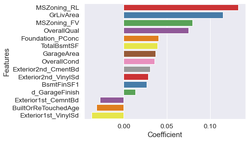

```python
# bar plot to determine the variables that would affect pricing most using ridge regression

plt.figure(figsize=(20,20))
plt.subplot(4,3,1)
sns.barplot(y = 'Features', x='Coefficient', palette='Set1', data = temp2_df)
plt.show()
```

## Conclusion

- The optimal lambda value in case of Ridge and Lasso is as below: Ridge - 0.4 Lasso - 0.0001
- The Mean Squared error in case of Ridge and Lasso are:

  Ridge -

  ```
         - MSE: 0.015888159710745184
         - RMSE : 0.1260482435845307
  ```

  Lasso -

  ```
         - MSE : 0.01578521041943166
         - RMSE : 0.125639207333665
  ```

- The Mean Squared Error of Lasso is slightly lower than that of Ridge . Also, since Lasso helps in feature reduction (as the coefficient value of one of the feature became 0), Lasso has a better edge over Ridge.
- Hence the factors that generally affect an increase in the price are :

  ```
        - Zoning classification,especially Low Density Residentials
        - Living area square feet,
        - Overall quality and condition of the house,
        - Foundation type of the house, especially Poured Contrete
        - Garage area that can  accomodated higher number of cars
        - Total basement area in square feet
        - Basement finished square feet area
        - 2nd Exterior 1st Exteriors like Vinyl Siding,Cement Board covering on house
  ```

- ALso the factors that generally affect an decrease in the price are :

  ```
        - An increase in the Age of property
        - 1st Exteriors like Vinyl Siding,Cement Board,Wood Siding covering on house
  ```